# Client Report - Project 4: Can You Predict That?

- Show All Code
- Hide All Code

Course DS 250

Author

Diego Scarpa

### Project 4: Can You Predict That?

### Elevator pitch

*The Gradient Boosting Model had good accuracy of 86%. It worked well to classify houses built before or after 1980. The model’s precision was 88%, and recall was 90%. The most important features were numbaths, basement, and livearea. These results show that the model is useful and easy to understand for making decisions.*

**Read and format project data**

```python
# Include and execute your code here
url = "https://github.com/byuidatascience/data4dwellings/raw/master/data-raw/dwellings_ml/dwellings_ml.csv"

data = pd.read_csv(url)
print("")
print("Columns in the dataset:")
print(data.columns)
print("")
print(data.shape)
print("")

value_counts = data['before1980'].value_counts()

print(value_counts)
data['YearBuiltLabel'] = data['before1980'].replace({0: 'After1980', 1: 'Before1980'})
data['YearBuiltLabel'] = pd.Categorical(data['YearBuiltLabel'], categories=['Before1980', 'After1980'], ordered=True)
```

```
Columns in the dataset:
Index(['parcel', 'abstrprd', 'livearea', 'finbsmnt', 'basement', 'yrbuilt',
       'totunits', 'stories', 'nocars', 'numbdrm', 'numbaths', 'sprice',
       'deduct', 'netprice', 'tasp', 'smonth', 'syear', 'condition_AVG',
       'condition_Excel', 'condition_Fair', 'condition_Good',
       'condition_VGood', 'quality_A', 'quality_B', 'quality_C', 'quality_D',
       'quality_X', 'gartype_Att', 'gartype_Att/Det', 'gartype_CP',
       'gartype_Det', 'gartype_None', 'gartype_att/CP', 'gartype_det/CP',
       'arcstyle_BI-LEVEL', 'arcstyle_CONVERSIONS', 'arcstyle_END UNIT',
       'arcstyle_MIDDLE UNIT', 'arcstyle_ONE AND HALF-STORY',
       'arcstyle_ONE-STORY', 'arcstyle_SPLIT LEVEL', 'arcstyle_THREE-STORY',
       'arcstyle_TRI-LEVEL', 'arcstyle_TRI-LEVEL WITH BASEMENT',
       'arcstyle_TWO AND HALF-STORY', 'arcstyle_TWO-STORY', 'qualified_Q',
       'qualified_U', 'status_I', 'status_V', 'before1980'],
      dtype='object')

(22913, 51)

before1980
1    14319
0     8594
Name: count, dtype: int64
```

### QUESTION|TASK 1

**Create charts that evaluate potential relationships between the home variables and before1980.**

**Read and format data**

```python
# Include and execute your code here
# Include import statements here
# Include reading data statements here

#<5000 Live Area
data = data[data['livearea'] <= 5000]
data = data[data['sprice'] <= 1500000]

value_counts = data['before1980'].value_counts()

print(value_counts)
```

```
before1980
1    14246
0     8048
Name: count, dtype: int64
```

**plot example**

```python
# Include and execute your code here
LetsPlot.setup_html()

#Boxplot
plot1 = (ggplot(data, aes(x='YearBuiltLabel', y='livearea', fill='YearBuiltLabel'))
         + geom_boxplot()
         + ggtitle('Living Area Distribution by Year Built'))



plot2 = (ggplot(data, aes(x='YearBuiltLabel', y='numbaths', fill='YearBuiltLabel'))
         + geom_boxplot()
         + ggtitle('Bathroom Count by Year Built'))



plot3 = (ggplot(data, aes(x='YearBuiltLabel', y='numbdrm', fill='YearBuiltLabel'))
         + geom_boxplot()
         + ggtitle('Bedroom Count by Year Built'))



plot4 = (ggplot(data, aes(x='YearBuiltLabel', y='sprice', fill='YearBuiltLabel'))
         + geom_boxplot()
         + ggtitle('Sale Price Distribution by Year Built'))



plot5 = (ggplot(data, aes(x='YearBuiltLabel', y='nocars', fill='YearBuiltLabel'))
         + geom_boxplot()
         + ggtitle('Garage Car Capacity by Year Built'))




plot6 = (ggplot(data, aes(x='YearBuiltLabel', y='basement', fill='YearBuiltLabel'))
         + geom_boxplot()
         + ggtitle('Basement SqFt Distribution by Year Built'))

#violin

violin_plot1 = (ggplot(data, aes(x='YearBuiltLabel', y='livearea', fill='YearBuiltLabel'))
                + geom_violin(trim=True)
                + ggtitle('Living Area Distribution by Year Built')
                + theme(axis_text_x=element_text(angle=45, hjust=1)))


# Heat map

numeric_cols = ['livearea', 'numbaths', 'numbdrm', 'sprice', 'nocars', 'basement','syear','totunits']
correlation_matrix = data[numeric_cols].corr().reset_index().melt(id_vars='index', var_name='Variable1', value_name='Correlation')
correlation_matrix.rename(columns={'index': 'Variable2'}, inplace=True)

heat_map = (ggplot(correlation_matrix, aes(x='Variable1', y='Variable2', fill='Correlation'))
            + geom_tile()
            + scale_fill_gradient2(low='#d7191c', mid='#ffffbf', high='#1a9641', midpoint=0)
            + ggtitle('Heat Map of Correlations'))



plot1.show()
plot2.show()
plot3.show()
plot4.show()
plot5.show()
plot6.show()
violin_plot1.show()
heat_map.show()
```

[output not shown]

### QUESTION|TASK 2

**Build a classification model labeling houses as being built “before 1980” or “during or after 1980”**

**Read and format data**

```python
# Include and execute your code here


from sklearn.model_selection import train_test_split

X = data[['livearea', 'numbaths', 'numbdrm', 'sprice', 'nocars', 'basement','netprice']]
y = data['before1980']


X = pd.get_dummies(X, drop_first=True)


X_train, X_test, y_train, y_test = train_test_split(X, y, test_size=0.25, random_state=42)
```

**Random Forest**

**Read and format data**

```python
# Include and execute your code here
from sklearn.ensemble import RandomForestClassifier
from sklearn.metrics import accuracy_score

# Train Random Forest
rf_model = RandomForestClassifier(random_state=42, n_estimators=100, max_depth=5)
rf_model.fit(X_train, y_train)

# Prediction & Score
y_pred_rf = rf_model.predict(X_test)
accuracy_rf = accuracy_score(y_test, y_pred_rf)
print(f"Random Forest Accuracy: {accuracy_rf:.4f}")
```

```
Random Forest Accuracy: 0.8086
```

**Logistic Regression**

**Read and format data**

```python
# Include and execute your code here
from sklearn.linear_model import LogisticRegression

# TRain Logistic Regression
log_model = LogisticRegression()
log_model.fit(X_train, y_train)

# Prediction & Score
y_pred_log = log_model.predict(X_test)
accuracy_log = accuracy_score(y_test, y_pred_log)
print(f"Logistic Regression Accuracy: {accuracy_log:.4f}")
```

```
Logistic Regression Accuracy: 0.5562
```

**Gradient Boosting**

**Read and format data**

```python
# Include and execute your code here
from sklearn.ensemble import GradientBoostingClassifier

# Train Gradient Boosting
gb_model = GradientBoostingClassifier(n_estimators=100, learning_rate=0.1, max_depth=5, random_state=42)
gb_model.fit(X_train, y_train)

# Prediction & Score
y_pred_gb = gb_model.predict(X_test)
accuracy_gb = accuracy_score(y_test, y_pred_gb)
print(f"Gradient Boosting Accuracy: {accuracy_gb:.4f}")
```

```
Gradient Boosting Accuracy: 0.8558
```

**K-Nearest Neighbors**

**Read and format data**

```python
# Include and execute your code here

from sklearn.neighbors import KNeighborsClassifier

# Train KNN
knn_model = KNeighborsClassifier(n_neighbors=5)
knn_model.fit(X_train, y_train)

# Prediction & Score
y_pred_knn = knn_model.predict(X_test)
accuracy_knn = accuracy_score(y_test, y_pred_knn)
print(f" K-Nearest Neighbors Accuracy: {accuracy_knn:.4f}")
```

```
 K-Nearest Neighbors Accuracy: 0.7072
```

### QUESTION|TASK 3

**Justify your classification model by discussing the most important features selected by your model.**

**plot example**

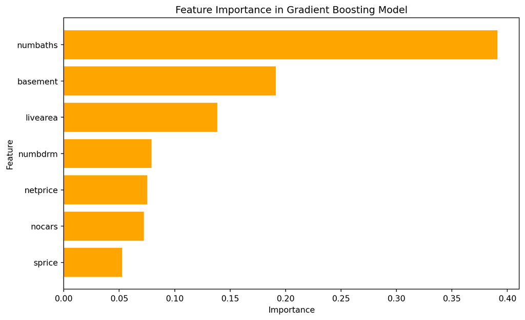

My useless chart

```python
# Include and execute your code here

feature_importances = gb_model.feature_importances_
features = X.columns

# Plot importance scores
importance_df = pd.DataFrame({'Feature': features, 'Importance': feature_importances}).sort_values(by='Importance', ascending=False)

plt.figure(figsize=(10, 6))
plt.barh(importance_df['Feature'], importance_df['Importance'], color='orange')
plt.xlabel('Importance')
plt.ylabel('Feature')
plt.title('Feature Importance in Gradient Boosting Model')
plt.gca().invert_yaxis()
plt.show()
```

### QUESTION|TASK 4

**Describe the quality of your classification model using 2-3 different evaluation metrics.**

**Read and format data**

```python
# Include and execute your code here

from sklearn.ensemble import GradientBoostingClassifier
from sklearn.metrics import accuracy_score, precision_score, recall_score, classification_report


accuracy = accuracy_score(y_test, y_pred_gb)
precision = precision_score(y_test, y_pred_gb)
recall = recall_score(y_test, y_pred_gb)

print(f"Accuracy: {accuracy:.2f}")
print(f"Precision: {precision:.2f}")
print(f"Recall: {recall:.2f}")


print("\nClassification Report:")
print(classification_report(y_test, y_pred_gb))
```

```
Accuracy: 0.86
Precision: 0.88
Recall: 0.90

Classification Report:
              precision    recall  f1-score   support

           0       0.81      0.78      0.80      2023
           1       0.88      0.90      0.89      3551

    accuracy                           0.86      5574
   macro avg       0.85      0.84      0.84      5574
weighted avg       0.85      0.86      0.86      5574
```